# Student Performance

Marcos Fernandez Fernandez

2022-06-17

# Introduction

Education is one of the most important aspects of human development. The Student’s performance plays a crucial role in making quality graduates that will in terms become great leaders that are responsible for the development of our country. Academic achievements, such as secondary school diplomas and bachelor degrees, are one of the major factors considered by employers in hiring workers. Adults who are academically successful and with high levels of education are more likely to be employed, have stable employment, have more employment opportunities, and earn higher salaries than those with less education. Thus, students have to put the greatest effort in their study to obtain good grades and to prepare themselves for future opportunities in their career at the same time to fulfill the employer’s demand.

## Student Performance

Research has shown dropout and repetition rates appear to be most common among students from low socio-economic backgrounds. Which in other words means that student’s academic performance is being affected by factors which include, the students’ learning skills, parental background, peer influence, teachers’ quality, learning infrastructure among others.

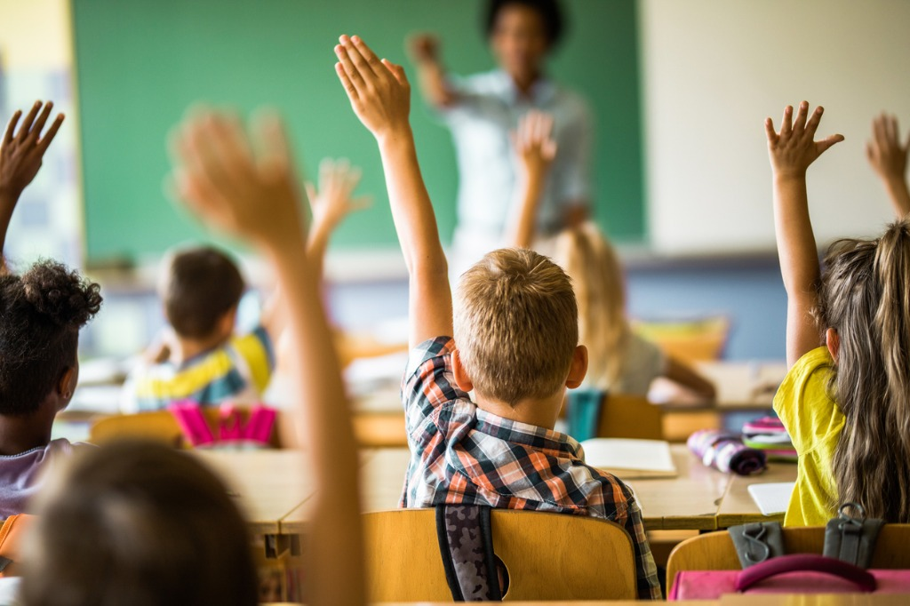

Children in Classroom

## Data Sets

In the first data set, we will explore a survey done to students in a secondary school math course.This data set compares family relations of the student with their school performance. Some of the variables include: gender, age, size of family, Father education, Mother education, Occupation of Father and Mother, Family Relation, Health, and Grades.

(Data set by Dev Ansodariya)

```
##   school sex age address famsize Pstatus Medu Fedu     Mjob     Fjob     reason
## 1     GP   F  18       U     GT3       A    4    4  at_home  teacher     course
## 2     GP   F  17       U     GT3       T    1    1  at_home    other     course
## 3     GP   F  15       U     LE3       T    1    1  at_home    other      other
## 4     GP   F  15       U     GT3       T    4    2   health services       home
## 5     GP   F  16       U     GT3       T    3    3    other    other       home
## 6     GP   M  16       U     LE3       T    4    3 services    other reputation
##   guardian traveltime studytime failures schoolsup famsup paid activities
## 1   mother          2         2        0       yes     no   no         no
## 2   father          1         2        0        no    yes   no         no
## 3   mother          1         2        3       yes     no  yes         no
## 4   mother          1         3        0        no    yes  yes        yes
## 5   father          1         2        0        no    yes  yes         no
## 6   mother          1         2        0        no    yes  yes        yes
##   nursery higher internet romantic famrel freetime goout Dalc Walc health
## 1     yes    yes       no       no      4        3     4    1    1      3
## 2      no    yes      yes       no      5        3     3    1    1      3
## 3     yes    yes      yes       no      4        3     2    2    3      3
## 4     yes    yes      yes      yes      3        2     2    1    1      5
## 5     yes    yes       no       no      4        3     2    1    2      5
## 6     yes    yes      yes       no      5        4     2    1    2      5
##   absences G1 G2 G3
## 1        6  5  6  6
## 2        4  5  5  6
## 3       10  7  8 10
## 4        2 15 14 15
## 5        4  6 10 10
## 6       10 15 15 15
```

On the other hand, the second data set consists of the marks secured by the students in various subjects. In this data set we can see the student’s parents background as well as test preparation, and how it may influence student performance.

(Data set by Bharti Prasad)

```
##   gender race.ethnicity parental.level.of.education        lunch
## 1 female        group B           bachelor's degree     standard
## 2 female        group C                some college     standard
## 3 female        group B             master's degree     standard
## 4   male        group A          associate's degree free/reduced
## 5   male        group C                some college     standard
## 6 female        group B          associate's degree     standard
##   test.preparation.course math.score reading.score writing.score
## 1                    none         72            72            74
## 2               completed         69            90            88
## 3                    none         90            95            93
## 4                    none         47            57            44
## 5                    none         76            78            75
## 6                    none         71            83            78
```

# Data Analysis

Before we begin, the data sets have to be prepared so that they can be compared among each other.

```
##   G1 G2 G3 Percentage
## 1  5  6  6   28.33333
## 2  5  5  6   26.66667
## 3  7  8 10   41.66667
## 4 15 14 15   73.33333
## 5  6 10 10   43.33333
## 6 15 15 15   75.00000
```

```
##   math.score reading.score writing.score Percentage
## 1         72            72            74   72.66667
## 2         69            90            88   82.33333
## 3         90            95            93   92.66667
## 4         47            57            44   49.33333
## 5         76            78            75   76.33333
## 6         71            83            78   77.33333
```

## Gender vs Student Performance

Now that we have the grade percentage for all the students, we can start looking for factors that influence a student’s academic performance. First, we can begin comparing the students by gender.

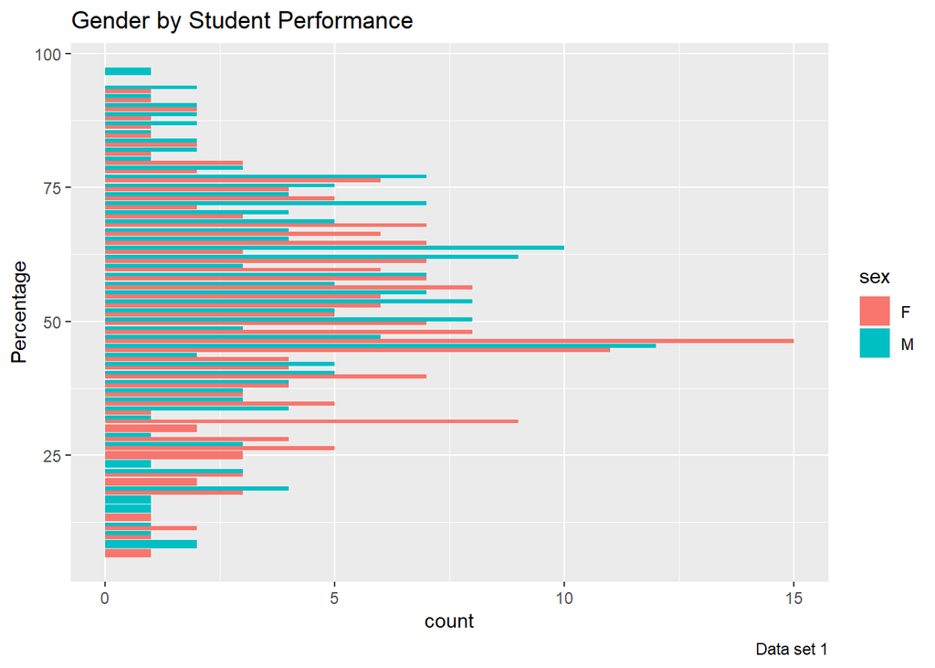

```
## # A tibble: 2 x 2
##   sex   Percentage
##   <chr>      <dbl>
## 1 F           51.6
## 2 M           55.4
```

According to the first data set, female students have a lower grade point average than male students.

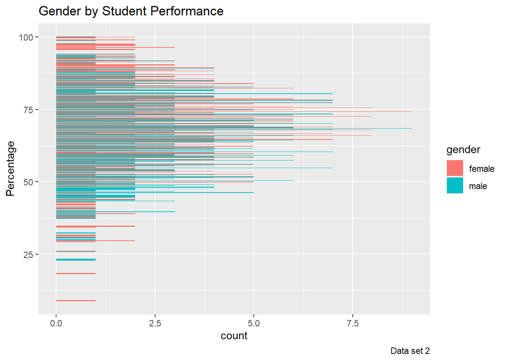

```
## # A tibble: 2 x 2
##   gender Percentage
##   <chr>       <dbl>
## 1 female       69.6
## 2 male         65.8
```

But when we look at the second data set, we can see that female students now have a higher grade point average than male students. So in other words, gender does not influence a student’s academic performance.

## Parent’s Education vs Student Performance

Now we take a look at the academic level achieved by a student’s parent and compare it to the grade point average achieved by their child.

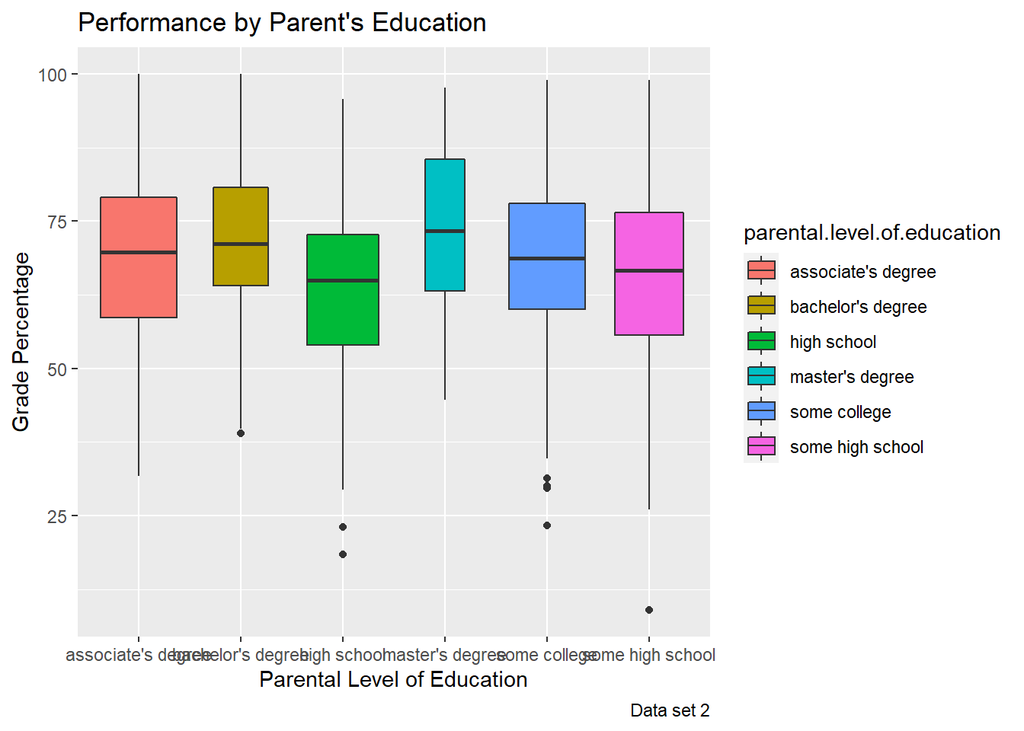

Based off the second data set, we can see that students whose parents achieved higher education perform better in school.

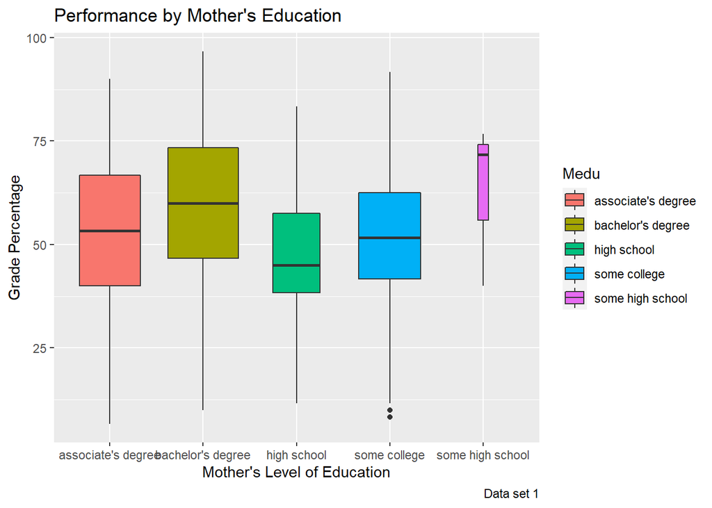

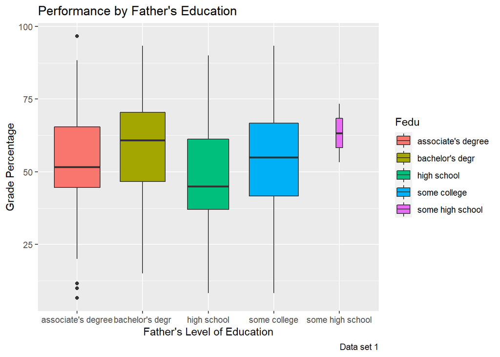

## Internet vs Student Perfromance

Next we will take a look at how performance is affected by the lack of internet at a student’s household

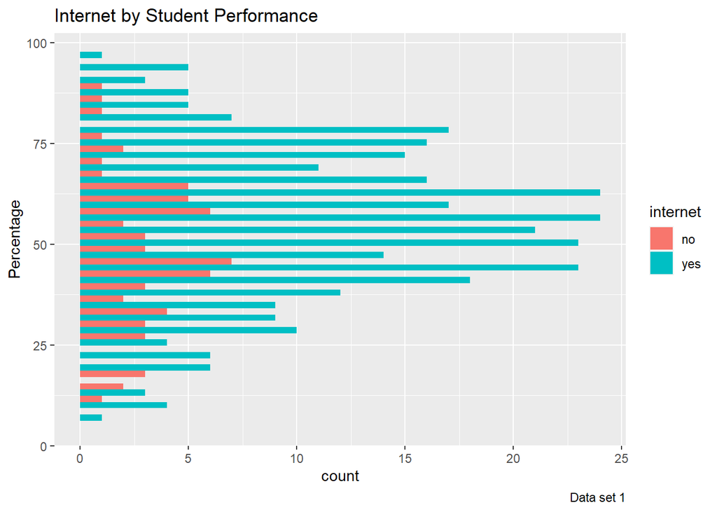

```
## # A tibble: 2 x 2
##   internet Percentage
##   <chr>         <dbl>
## 1 no             49.2
## 2 yes            54.2
```

Based on the graph and the two averages, we can conclude that the lack of internet is affecting the academic performance of a student.

## Parent Job vs Student Performance

Lastly we will compare the student’s performance by what their parents do for a living.

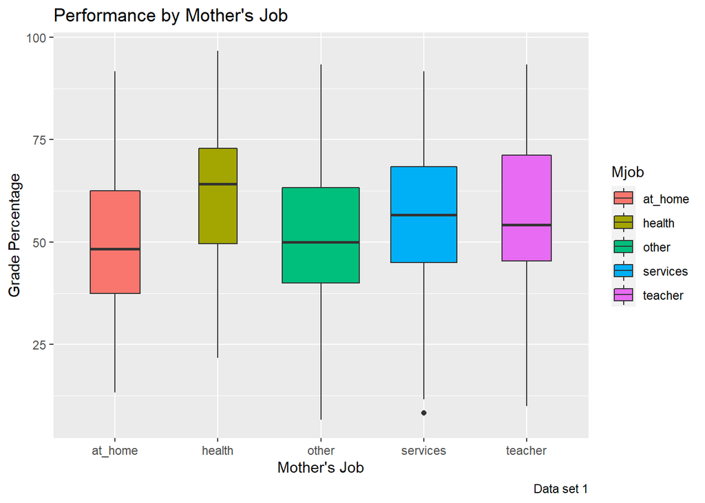

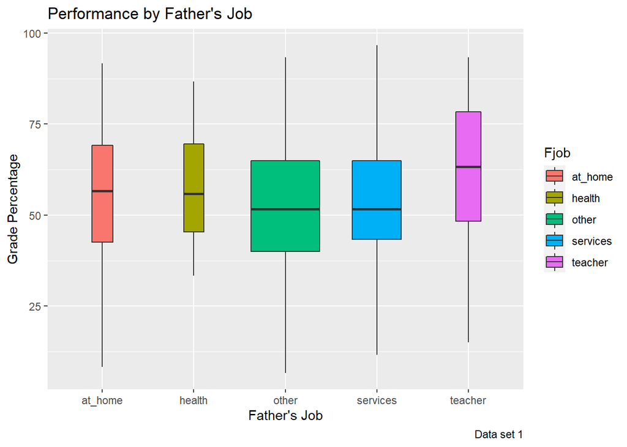

According to the graphics, students with a mother in the medical field will perform better in school, and students with a father who works as a teacher will also be better in school.

# Conclusion

To conclude, a students performance in school does not depend on the gender they are but their family situation. A student with well educated parents, that work in fields such as medicine and education, will have a more supportive and helpful relation from their parents which in terms will boost their academic performance. Also factors such as lack of internet can also cause a student to perform poorly in school.

## Sources

Data set 1: https://www.kaggle.com/code/devansodariya/student-performance-analytics/data

Data set 2: https://www.kaggle.com/code/bhartiprasad17/student-academic-performance-analysis/data